# Drivers of data structure

Jeff Powell

23 September 2019

Up to this point, we have used ordination to look for structure in multivariate data. Once that structure is observed, you may have ideas about what factors are driving that structure and would like to test the hypotheses that these factors are actually important. To do this is to apply a constraint to the data, partitioning variation in the data to specific factors, or linear combinations of these specific factors (as above), and then comparing this partitioned variation to any remaining variation in the data.

Here we use the `phyloseq` object called `phy` that we generated during the first chapter and modified in the second chapter. This object has been manipulated to include only OTUs that have been classified as fungi and successfully classified at the phylum level. OTU data were hellinger-transformed and excluded five samples that had low read counts.

# ‘Experimental’ frameworks: working with factors

## Cluster analysis

We often collect multivariate data in the context of experimental studies or in the context of observed categorical explanatory variables that are of interest. We could perform ANOVA for each variable individually, but this amplifies the potential for Type I error and does not account for potential collinearity among response variables. In addition, we may not be interested in particular response variables, but in how multiple variables are responding as a whole.

We have already seen strong separation in our data by sample type and weak separation by fertilizer treatment through ordination. We can also visualise this by plotting hierarchical clusters. We will use the complete-linkage algorithm, which is the default and aims to maximise the distances among clusters, but other algorithms are available and may be more appropriate.

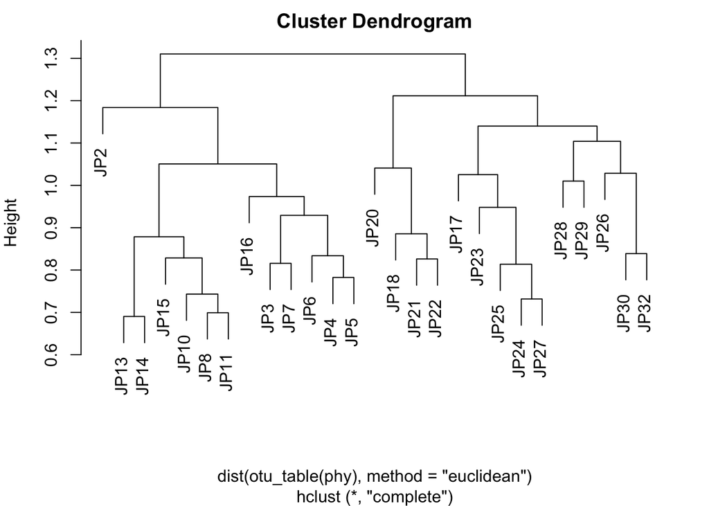

```r
# set plot margins
par(mar=c(5,4,2,2))

# plot hclust result, using distance matrix and input
plot(hclust(dist(otu_table(phy), method='euclidean')))
```

The label on the tips represent the rownames in the OTU matrix but are not very informative on their own. Here it is useful to provide a more informative vector with which to label the tips.

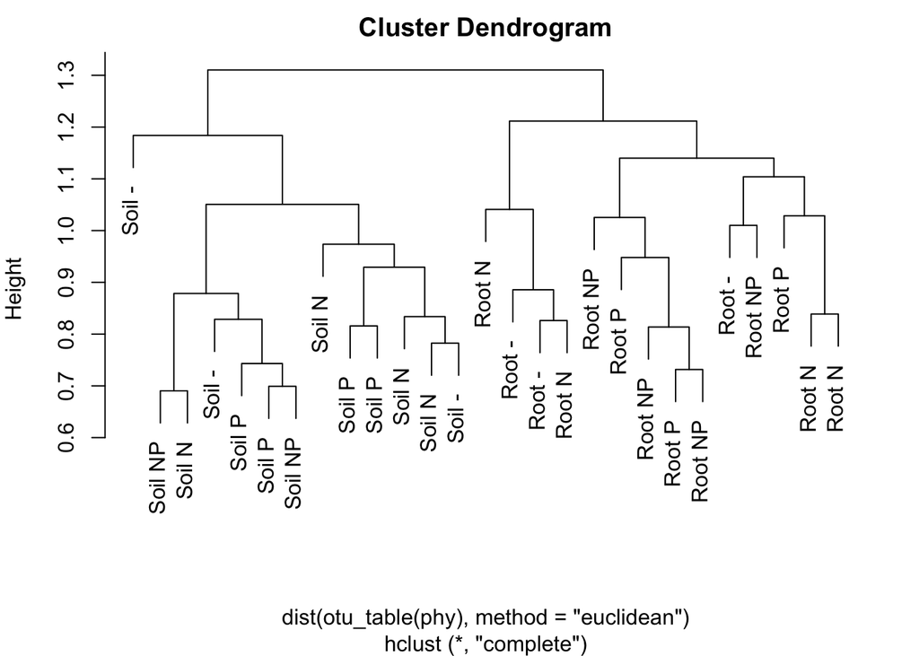

```r
# set plot margins
par(mar=c(5,4,2,2))

# manipulate labels to include in the plot
# first select columns to use
temp <- select(sample_data(phy), Treatment, SampleType)
# then change labels of legend to something shorter
levels(temp$Treatment) <- c('-', 'N', 'P', 'NP')
levels(temp$SampleType) <- c('Root', 'Soil')
# then combine the two factors into a single vector
temp$trt <- with(temp, interaction(SampleType, Treatment, sep=' '))

# plot output of hierarchical clustering using custom labels
plot(hclust(dist(otu_table(phy), method='euclidean')),
     labels=temp$trt)
```

```r
# tidy workspace
rm(temp)
```

## Statistical testing

We need a statistical tool to test the hypothesis that fungal communities within each group are more similar to each other than to those under other groups.

Analysis of similarities (ANOSIM) is one approach to test this hypothesis, using the `anosim` function in the `vegan` package. This is a nonparametric test; distances are transformed into ranks and the mean of the ranks for distances classified as within the groups is compared to that for the between-group distance ranks. However, there are concerns about how ANOSIM results should be interpreted (also mentioned on the help page for the function) and PerMANOVA (Permutational ANOVA) is usually preferred.

PerMANOVA is potentially more powerful than ANOSIM because the distances are preserved and not rank-transformed; the approach partitions variance among and within groups through calculations of sums of squared distances and calculates pseudo $F$-statistics. In addition, it is possible to estimate the effects associated with multiple factors and their interactions. The function to perform PerMANOVA is `adonis` within `vegan` and the result is interpreted in the same way as an ANOVA table.

```r
# extract sample data and change to data.frame class
# note that 'as.data.frame' leaves as 'sample_data' object,
# which does not work with adonis
dat <- data.frame(sample_data(phy))

# perform PerMANOVA using Euclidean distances (for RDA)
adonis(dist(otu_table(phy), method='euclidean') ~ SampleType * Treatment,
       data=dat)
```

```
##
## Call:
## adonis(formula = dist(otu_table(phy), method = "euclidean") ~      SampleType * Treatment, data = dat)
##
## Permutation: free
## Number of permutations: 999
##
## Terms added sequentially (first to last)
##
##                      Df SumsOfSqs MeanSqs F.Model      R2 Pr(>F)
## SampleType            1    3.0430 3.04295  6.8082 0.20874  0.001 ***
## Treatment             3    1.9294 0.64313  1.4389 0.13235  0.025 *
## SampleType:Treatment  3    1.1133 0.37111  0.8303 0.07637  0.833
## Residuals            19    8.4921 0.44695         0.58254
## Total                26   14.5778                 1.00000
## ---
## Signif. codes:  0 '***' 0.001 '**' 0.01 '*' 0.05 '.' 0.1 ' ' 1
```

Because we used blocking in our experimental design, we should include `BlockID` as the `strata` argument to constrain permutations to within this group. Note that we cannot do this for `PlotID` to account for multiple sample types since this would not allow for correct reshuffling of `Treatment` labels.

```r
# perform PerMANOVA using Euclidean distances (for RDA), with strata
adonis(dist(otu_table(phy), method='euclidean') ~ SampleType * Treatment,
       data=dat, strata=dat$BlockID)
```

```
##
## Call:
## adonis(formula = dist(otu_table(phy), method = "euclidean") ~      SampleType * Treatment, data = dat, strata = dat$BlockID)
##
## Blocks:  strata
## Permutation: free
## Number of permutations: 999
##
## Terms added sequentially (first to last)
##
##                      Df SumsOfSqs MeanSqs F.Model      R2 Pr(>F)
## SampleType            1    3.0430 3.04295  6.8082 0.20874  0.001 ***
## Treatment             3    1.9294 0.64313  1.4389 0.13235  0.016 *
## SampleType:Treatment  3    1.1133 0.37111  0.8303 0.07637  0.678
## Residuals            19    8.4921 0.44695         0.58254
## Total                26   14.5778                 1.00000
## ---
## Signif. codes:  0 '***' 0.001 '**' 0.01 '*' 0.05 '.' 0.1 ' ' 1
```

There appears to be a weak effect of `Treatment` but we can’t tell how the levels differ from each other using this result. Functions in the `pairwiseAdonis` library produce pairwise comparisons – `pairwise.adonis` is appropriate when making comparisons within a single factor. Here we use `pairwise.adonis2` to constrain permutations to within levels of `SampleType`.

```r
# load library
library(pairwiseAdonis)

# test comparisons
pairwise.adonis2(dist(otu_table(phy), method='euclidean') ~ Treatment,
       data=dat, strata='SampleType')
```

```
## $parent_call
## [1] "dist(otu_table(phy), method = \"euclidean\") ~ Treatment , strata = SampleType"
##
## $control_vs_P
## Blocks:  strata
## Permutation: free
## Number of permutations: 999
##
## Terms added sequentially (first to last)
##
##           Df SumsOfSqs MeanSqs F.Model      R2 Pr(>F)
## Treatment  1    0.6054 0.60545  1.0988 0.09082   0.07 .
## Residuals 11    6.0612 0.55102         0.90918
## Total     12    6.6667                 1.00000
## ---
## Signif. codes:  0 '***' 0.001 '**' 0.01 '*' 0.05 '.' 0.1 ' ' 1
##
## $control_vs_N
## Blocks:  strata
## Permutation: free
## Number of permutations: 999
##
## Terms added sequentially (first to last)
##
##           Df SumsOfSqs MeanSqs F.Model      R2 Pr(>F)
## Treatment  1    0.5274 0.52735  0.8966 0.06952  0.317
## Residuals 12    7.0581 0.58817         0.93048
## Total     13    7.5854                 1.00000
##
## $control_vs_NP
## Blocks:  strata
## Permutation: free
## Number of permutations: 999
##
## Terms added sequentially (first to last)
##
##           Df SumsOfSqs MeanSqs F.Model      R2 Pr(>F)
## Treatment  1    0.7252 0.72522  1.2545 0.11147   0.05 *
## Residuals 10    5.7807 0.57807         0.88853
## Total     11    6.5060                 1.00000
```

[output cut: 30 more lines]

```
## Blocks:  strata
## Permutation: free
## Number of permutations: 999
##
## Terms added sequentially (first to last)
##
##           Df SumsOfSqs MeanSqs F.Model      R2 Pr(>F)
## Treatment  1    0.6815 0.68150  1.2395 0.09362   0.05 *
## Residuals 12    6.5977 0.54981         0.90638
## Total     13    7.2792                 1.00000
## ---
## Signif. codes:  0 '***' 0.001 '**' 0.01 '*' 0.05 '.' 0.1 ' ' 1
##
## attr(,"class")
## [1] "pwadstrata" "list"
```

From this it looks like there are differences when the levels differ in whether phosphorus was added. Alternatively, in this case, we could separate the effects of N and P, as follows:

```r
# split 'Treatment' into separate variables for 'N' and 'P'
dat$N <- factor(with(dat, ifelse(Treatment %in% c('N', 'NP'), 'yesN', 'noN')))
dat$P <- factor(with(dat, ifelse(Treatment %in% c('P', 'NP'), 'yesP', 'noP')))

# perform PerMANOVA using Euclidean distances (for RDA)
adonis(dist(otu_table(phy), method='euclidean') ~ SampleType * N * P,
       data=dat, strata=dat$BlockID)
```

```
##
## Call:
## adonis(formula = dist(otu_table(phy), method = "euclidean") ~      SampleType * N * P, data = dat, strata = dat$BlockID)
##
## Blocks:  strata
## Permutation: free
## Number of permutations: 999
##
## Terms added sequentially (first to last)
##
##                Df SumsOfSqs MeanSqs F.Model      R2 Pr(>F)
## SampleType      1    3.0430 3.04295  6.8082 0.20874  0.001 ***
## N               1    0.6560 0.65605  1.4678 0.04500  0.067 .
## P               1    0.8095 0.80953  1.8112 0.05553  0.021 *
## SampleType:N    1    0.3649 0.36486  0.8163 0.02503  0.577
## SampleType:P    1    0.3917 0.39170  0.8764 0.02687  0.441
## N:P             1    0.4579 0.45790  1.0245 0.03141  0.257
## SampleType:N:P  1    0.3627 0.36267  0.8114 0.02488  0.635
## Residuals      19    8.4921 0.44695         0.58254
## Total          26   14.5778                 1.00000
## ---
## Signif. codes:  0 '***' 0.001 '**' 0.01 '*' 0.05 '.' 0.1 ' ' 1
```

An assumption of these analyses is that the dispersion (variance) is not different among groups. We can test this assumption with the `betadisper` function.

```r
# test for 'SampleType', which has the most power.
anova(betadisper(dist(otu_table(phy), method='euclidean'), dat$SampleType))
```

```
## Analysis of Variance Table
##
## Response: Distances
##           Df   Sum Sq   Mean Sq F value  Pr(>F)
## Groups     1 0.023171 0.0231709  2.9725 0.09704 .
## Residuals 25 0.194877 0.0077951
## ---
## Signif. codes:  0 '***' 0.001 '**' 0.01 '*' 0.05 '.' 0.1 ' ' 1
```

The test is not significant so we can assume that the assumption is not violated.

# Canonical analysis - observational frameworks

By combining ordination techniques and multiple linear regression, we can use regression approaches to explain variation in one multivariate data table by variation in another multivariate data table from observations of the same objects. Prior to the availability of suitable software programs, principal components were extracted from the ordination of the explanatory matrix and then related to the ordination of the response matrix; this approach is named indirect gradient analysis. It has gradually been replaced by canonical analysis, or direct gradient analysis, in which the explanatory matrix is directly involved in the ordination of the response matrix.

## Modifying the explanatory variables

```r
# extract the sample data from the 'phyloseq' object
dat <- data.frame(sample_data(phy))
str(dat)
```

```
## 'data.frame':    27 obs. of  23 variables:
##  $ SampleID           : chr  "JP2" "JP3" "JP4" "JP5" ...
##  $ SampleType         : Factor w/ 2 levels "root","soil": 2 2 2 2 2 2 2 2 2 2 ...
##  $ PlotID             : Factor w/ 16 levels "3","4","5","8",..: 16 13 14 12 9 11 8 3 7 2 ...
##  $ BlockID            : Factor w/ 4 levels "1","2","3","4": 4 4 4 3 3 3 3 1 2 1 ...
##  $ Treatment          : Factor w/ 4 levels "control","N",..: 1 3 2 1 2 3 3 3 4 4 ...
##  $ Microbial_Biomass_C: num  2.12 2.4 2.19 2.15 1.85 ...
##  $ Microbial_N        : num  0.194 0.257 0.166 0.174 0.156 0.114 0.126 0.123 0.157 0.118 ...
##  $ Microbial_P        : num  0.071 0.349 0.198 0.055 0.198 0.143 0.184 0.331 0.062 0.061 ...
##  $ Total_C_mg_g_soil  : num  297.2 68.7 110.9 393.5 93.5 ...
##  $ Total_N_mg_g_soil  : num  27.26 7.35 8.42 31.91 7.85 ...
##  $ Total_P_mg_g_soil  : num  3622 4814 7371 6313 3654 ...
##  $ X..Moisture        : num  13.6 14.2 15 14.6 15.1 ...
##  $ DOC_Soil           : num  0.229 0.251 0.235 0.227 0.328 0.202 0.247 0.305 0.123 0.083 ...
##  $ Extractable_N_Soil : num  0.014 0.009 0.011 0.006 0.008 0.006 0.011 0.009 0.014 0.011 ...
##  $ Extractable_P_Soil : num  0.002 0.101 0.049 0.002 0.049 0.032 0.052 0.107 0.002 0.007 ...
##  $ BG_Enz             : num  100.5 142.7 131.9 99.2 134.5 ...
##  $ NAG_Enz            : num  39.3 130.2 121.5 35.1 55.2 ...
##  $ LAP_Enz            : num  27.5 26.8 29.9 23.3 24.2 ...
##  $ N_Enz              : num  66.7 157 151.4 58.4 79.4 ...
##  $ PHOS_Enz           : num  477 343 903 333 544 ...
##  $ CN_Enz             : num  1.505 0.909 0.871 1.698 1.695 ...
##  $ NP_Enz             : num  0.14 0.457 0.168 0.175 0.146 ...
##  $ CP_Enz             : num  0.211 0.416 0.146 0.298 0.247 ...
```

```r
# remove the 'SampleID' column
dat <- select(dat, -SampleID)
```

The code below shows how you can extract continuous and categorical predictors into different dataframes.

```r
# continuous (numeric) variables
dat.con <- select_if(dat, is.numeric)
str(dat.con)
```

```
## 'data.frame':    27 obs. of  18 variables:
##  $ Microbial_Biomass_C: num  2.12 2.4 2.19 2.15 1.85 ...
##  $ Microbial_N        : num  0.194 0.257 0.166 0.174 0.156 0.114 0.126 0.123 0.157 0.118 ...
##  $ Microbial_P        : num  0.071 0.349 0.198 0.055 0.198 0.143 0.184 0.331 0.062 0.061 ...
##  $ Total_C_mg_g_soil  : num  297.2 68.7 110.9 393.5 93.5 ...
##  $ Total_N_mg_g_soil  : num  27.26 7.35 8.42 31.91 7.85 ...
##  $ Total_P_mg_g_soil  : num  3622 4814 7371 6313 3654 ...
##  $ X..Moisture        : num  13.6 14.2 15 14.6 15.1 ...
##  $ DOC_Soil           : num  0.229 0.251 0.235 0.227 0.328 0.202 0.247 0.305 0.123 0.083 ...
##  $ Extractable_N_Soil : num  0.014 0.009 0.011 0.006 0.008 0.006 0.011 0.009 0.014 0.011 ...
##  $ Extractable_P_Soil : num  0.002 0.101 0.049 0.002 0.049 0.032 0.052 0.107 0.002 0.007 ...
##  $ BG_Enz             : num  100.5 142.7 131.9 99.2 134.5 ...
##  $ NAG_Enz            : num  39.3 130.2 121.5 35.1 55.2 ...
##  $ LAP_Enz            : num  27.5 26.8 29.9 23.3 24.2 ...
##  $ N_Enz              : num  66.7 157 151.4 58.4 79.4 ...
##  $ PHOS_Enz           : num  477 343 903 333 544 ...
##  $ CN_Enz             : num  1.505 0.909 0.871 1.698 1.695 ...
##  $ NP_Enz             : num  0.14 0.457 0.168 0.175 0.146 ...
##  $ CP_Enz             : num  0.211 0.416 0.146 0.298 0.247 ...
```

```r
# categorical (factor) variables
dat.cat <- select_if(dat, is.factor)
str(dat.cat)
```

```
## 'data.frame':    27 obs. of  4 variables:
##  $ SampleType: Factor w/ 2 levels "root","soil": 2 2 2 2 2 2 2 2 2 2 ...
##  $ PlotID    : Factor w/ 16 levels "3","4","5","8",..: 16 13 14 12 9 11 8 3 7 2 ...
##  $ BlockID   : Factor w/ 4 levels "1","2","3","4": 4 4 4 3 3 3 3 1 2 1 ...
##  $ Treatment : Factor w/ 4 levels "control","N",..: 1 3 2 1 2 3 3 3 4 4 ...
```

When analysing the continuous variables, we need to decide whether it matters that they vary on the same scale or not. Variables that have a larger mean and, therefore, greater variance will contribute more to explaining variation in the data. This might be justified in some cases but in many cases comparing variables on the same absolute scale is not ecologically meaningful (e.g., concentrations of different nutrients that are required at different levels). In addition, the differences can come down to the the units in which the variable was measured (e.g., `%` versus `ppm`).

```r
# standardise the data to 'mean=0' and 'sd=1' (or as close as possible)
dat.con.std <- decostand(dat.con, method='standardize')

# check the results yourself
summary(dat.con.std)
```

Some functions allow for categorical variables in the model while others do not. To avoid problems, it is best to convert these to numeric variables, with each level within a category represented by a separate variable weighted by its frequency in the data. The code below shows you how to use functions in the `ade4` library to do this conversion. Note that we don’t load the library since it includes the function `ade4::cca`, which we do not want to mask `vegan::cca`.

```r
# for only categorical predictors
dat.hs <- ade4::dudi.hillsmith(dat.cat, scannf=F, nf=2)$tab
str(dat.hs)
```

```
## 'data.frame':    27 obs. of  26 variables:
##  $ Sampl.root   : num  -1 -1 -1 -1 -1 -1 -1 -1 -1 -1 ...
##  $ Sampl.soil   : num  1.08 1.08 1.08 1.08 1.08 ...
##  $ PlotI.3      : num  -1 -1 -1 -1 -1 -1 -1 -1 -1 -1 ...
##  $ PlotI.4      : num  -1 -1 -1 -1 -1 -1 -1 -1 -1 12.5 ...
##  $ PlotI.5      : num  -1 -1 -1 -1 -1 -1 -1 12.5 -1 -1 ...
##  $ PlotI.8      : num  -1 -1 -1 -1 -1 -1 -1 -1 -1 -1 ...
##  $ PlotI.16     : num  -1 -1 -1 -1 -1 -1 -1 -1 -1 -1 ...
##  $ PlotI.18     : num  -1 -1 -1 -1 -1 -1 -1 -1 -1 -1 ...
##  $ PlotI.21     : num  -1 -1 -1 -1 -1 -1 -1 -1 12.5 -1 ...
##  $ PlotI.22     : num  -1 -1 -1 -1 -1 -1 12.5 -1 -1 -1 ...
##  $ PlotI.29     : num  -1 -1 -1 -1 12.5 -1 -1 -1 -1 -1 ...
##  $ PlotI.32     : num  -1 -1 -1 -1 -1 -1 -1 -1 -1 -1 ...
##  $ PlotI.33     : num  -1 -1 -1 -1 -1 12.5 -1 -1 -1 -1 ...
##  $ PlotI.36     : num  -1 -1 -1 12.5 -1 -1 -1 -1 -1 -1 ...
##  $ PlotI.40     : num  -1 26 -1 -1 -1 -1 -1 -1 -1 -1 ...
##  $ PlotI.42     : num  -1 -1 12.5 -1 -1 -1 -1 -1 -1 -1 ...
##  $ PlotI.44     : num  -1 -1 -1 -1 -1 -1 -1 -1 -1 -1 ...
##  $ PlotI.45     : num  12.5 -1 -1 -1 -1 -1 -1 -1 -1 -1 ...
##  $ Block.1      : num  -1 -1 -1 -1 -1 ...
##  $ Block.2      : num  -1 -1 -1 -1 -1 -1 -1 -1 3.5 -1 ...
##  $ Block.3      : num  -1 -1 -1 2.38 2.38 ...
##  $ Block.4      : num  3.5 3.5 3.5 -1 -1 -1 -1 -1 -1 -1 ...
##  $ Treat.control: num  3.5 -1 -1 3.5 -1 -1 -1 -1 -1 -1 ...
##  $ Treat.N      : num  -1 -1 2.38 -1 2.38 ...
##  $ Treat.P      : num  -1 2.86 -1 -1 -1 ...
##  $ Treat.NP     : num  -1 -1 -1 -1 -1 -1 -1 -1 3.5 3.5 ...
```

```r
# for a mix of categorical and continuous predictors
dat.mix <- ade4::dudi.mix(dat, scannf=F, nf=2)$tab
str(dat.mix)
```

```
## 'data.frame':    27 obs. of  44 variables:
##  $ Sampl.root         : num  -1 -1 -1 -1 -1 -1 -1 -1 -1 -1 ...
##  $ Sampl.soil         : num  1.08 1.08 1.08 1.08 1.08 ...
##  $ PlotI.3            : num  -1 -1 -1 -1 -1 -1 -1 -1 -1 -1 ...
##  $ PlotI.4            : num  -1 -1 -1 -1 -1 -1 -1 -1 -1 12.5 ...
##  $ PlotI.5            : num  -1 -1 -1 -1 -1 -1 -1 12.5 -1 -1 ...
##  $ PlotI.8            : num  -1 -1 -1 -1 -1 -1 -1 -1 -1 -1 ...
##  $ PlotI.16           : num  -1 -1 -1 -1 -1 -1 -1 -1 -1 -1 ...
##  $ PlotI.18           : num  -1 -1 -1 -1 -1 -1 -1 -1 -1 -1 ...
##  $ PlotI.21           : num  -1 -1 -1 -1 -1 -1 -1 -1 12.5 -1 ...
##  $ PlotI.22           : num  -1 -1 -1 -1 -1 -1 12.5 -1 -1 -1 ...
##  $ PlotI.29           : num  -1 -1 -1 -1 12.5 -1 -1 -1 -1 -1 ...
##  $ PlotI.32           : num  -1 -1 -1 -1 -1 -1 -1 -1 -1 -1 ...
##  $ PlotI.33           : num  -1 -1 -1 -1 -1 12.5 -1 -1 -1 -1 ...
##  $ PlotI.36           : num  -1 -1 -1 12.5 -1 -1 -1 -1 -1 -1 ...
```

[output cut: 30 more lines]

```r
# note that all variables have been standardised
# check this yourself
# summary(dat.hs)
# summary(dat.mix)
```

In the examples below, we will focus only on the standardised continuous variables, although we will include our treatments in plotting.

## Choosing an approach

As for unconstrained ordination, there are several options and the choice of which to use depends on the characteristics of the data in the OTU matrix. Some of these approaches can be performed using `phyloseq` functions but they are no longer more convenient than the functions in `vegan` on which they are based. Therefore, we will use the `vegan` functions directly from here on out, with the occasional help from `QsRutils` functions.

```r
# extract the OTU table
Y <- veganotu(phy)

# extract the sample data from the 'phyloseq' object
# then remove the 'SampleID' column
dat <- data.frame(sample_data(phy))
dat <- select(dat, -SampleID)

# select the continuous variables to use in the constraint (Y)
# then standardise
X <- select_if(dat, is.numeric)
X <- decostand(X, method='standardize')
```

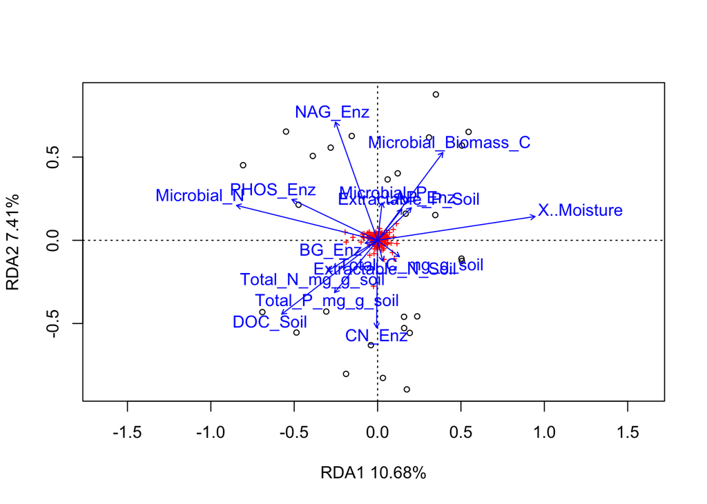

```r
# RDA
res <- rda(Y ~ ., data=X)
plot(res, xlab=ord_labels(res)[1], ylab=ord_labels(res)[2])
```

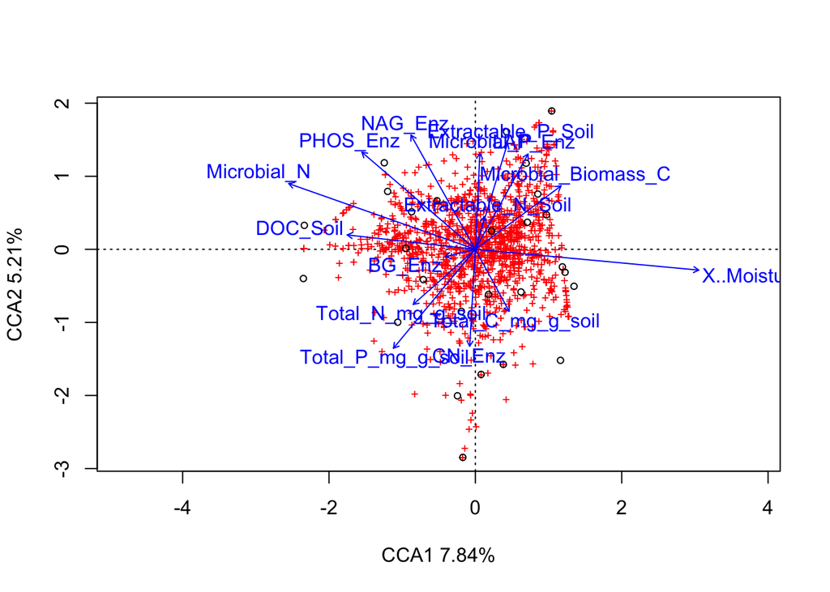

```r
# CCA
res <- cca(Y ~ ., data=X)
plot(res, xlab=ord_labels(res)[1], ylab=ord_labels(res)[2])
```

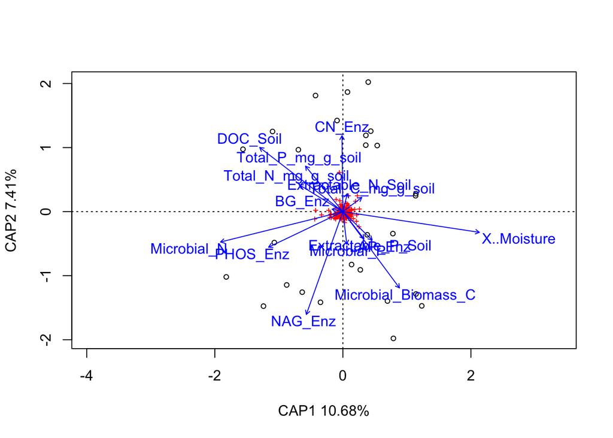

```r
# dbRDA
# note the result is the same as for RDA when using euclidean distances
res <- capscale(Y ~ ., data=X, distance='euclidean')
plot(res, xlab=ord_labels(res)[1], ylab=ord_labels(res)[2])
```

## Exploring the results further and statistical tests

```r
# use CLR-transformed OTU table
Y <- clrs

# RDA
res <- rda(Y ~ ., data=X)

# summary of the results
summary(res, display=NULL)
```

```
##
## Call:
## rda(formula = Y ~ Microbial_Biomass_C + Microbial_N + Microbial_P +      Total_C_mg_g_soil + Total_N_mg_g_soil + Total_P_mg_g_soil +      X..Moisture + DOC_Soil + Extractable_N_Soil + Extractable_P_Soil +      BG_Enz + NAG_Enz + LAP_Enz + N_Enz + PHOS_Enz + CN_Enz +      NP_Enz + CP_Enz, data = X…
##
## Partitioning of variance:
##               Inertia Proportion
## Total          1077.4     1.0000
## Constrained     614.6     0.5705
## Unconstrained   462.7     0.4295
##
## Eigenvalues, and their contribution to the variance
##
## Importance of components:
##                           RDA1     RDA2     RDA3     RDA4     RDA5
## Eigenvalue            83.20487 61.32795 48.46001 47.93305 45.36476
## Proportion Explained   0.07723  0.05692  0.04498  0.04449  0.04211
## Cumulative Proportion  0.07723  0.13415  0.17913  0.22362  0.26573
##                           RDA6     RDA7     RDA8     RDA9    RDA10
## Eigenvalue            43.62103 38.18436 36.98354 34.19341 33.92980
## Proportion Explained   0.04049  0.03544  0.03433  0.03174  0.03149
## Cumulative Proportion  0.30622  0.34166  0.37599  0.40772  0.43922
##                          RDA11   RDA12    RDA13    RDA14    RDA15      PC1
## Eigenvalue            31.90427 30.7101 28.09629 27.00507 23.72941 133.3928
## Proportion Explained   0.02961  0.0285  0.02608  0.02507  0.02203   0.1238
## Cumulative Proportion  0.46883  0.4973  0.52341  0.54848  0.57050   0.6943
##                            PC2      PC3      PC4      PC5      PC6
## Eigenvalue            44.76649 41.02186 36.24775 35.86485 33.21092
## Proportion Explained   0.04155  0.03808  0.03364  0.03329  0.03083
## Cumulative Proportion  0.73587  0.77394  0.80759  0.84087  0.87170
##                            PC7      PC8     PC9     PC10    PC11
## Eigenvalue            30.75645 29.72994 27.1497 26.35326 24.2379
## Proportion Explained   0.02855  0.02759  0.0252  0.02446  0.0225
## Cumulative Proportion  0.90025  0.92784  0.9530  0.97750  1.0000
##
## Accumulated constrained eigenvalues
## Importance of components:
##                          RDA1     RDA2     RDA3     RDA4     RDA5     RDA6
## Eigenvalue            83.2049 61.32795 48.46001 47.93305 45.36476 43.62103
## Proportion Explained   0.1354  0.09978  0.07884  0.07798  0.07381  0.07097
## Cumulative Proportion  0.1354  0.23515  0.31399  0.39197  0.46578  0.53675
##                           RDA7     RDA8     RDA9   RDA10    RDA11    RDA12
## Eigenvalue            38.18436 36.98354 34.19341 33.9298 31.90427 30.71010
## Proportion Explained   0.06212  0.06017  0.05563  0.0552  0.05191  0.04996
## Cumulative Proportion  0.59887  0.65904  0.71467  0.7699  0.82178  0.87175
##                          RDA13    RDA14    RDA15
## Eigenvalue            28.09629 27.00507 23.72941
## Proportion Explained   0.04571  0.04394  0.03861
## Cumulative Proportion  0.91746  0.96139  1.00000
##
## Scaling 2 for species and site scores
## * Species are scaled proportional to eigenvalues
## * Sites are unscaled: weighted dispersion equal on all dimensions
## * General scaling constant of scores:
```

```r
# permutation test of statistical significance
anova(res)
```

```
## Permutation test for rda under reduced model
## Permutation: free
## Number of permutations: 999
##
## Model: rda(formula = Y ~ Microbial_Biomass_C + Microbial_N + Microbial_P + Total_C_mg_g_soil + Total_N_mg_g_soil + Total_P_mg_g_soil + X..Moisture + DOC_Soil + Extractable_N_Soil + Extractable_P_Soil + BG_Enz + NAG_Enz + LAP_Enz + N_Enz + PHOS_Enz + CN_Enz + NP_Enz + CP_Enz, data = X)
##          Df Variance      F Pr(>F)
## Model    15   614.65 0.9741  0.637
## Residual 11   462.73
```

There are multiple approaches to select only the variables that are explaining variation efficiently.

1. Variance inflation factors (VIF)

```r
# calculate variance inflation
# variables with scores >10 are redundant
sort(vif.cca(res))
```

```
##            PHOS_Enz  Extractable_N_Soil   Total_P_mg_g_soil
##            6.574653            6.597692            8.538865
##         X..Moisture             LAP_Enz            DOC_Soil
##           11.745005           14.967555           17.870786
##         Microbial_N Microbial_Biomass_C  Extractable_P_Soil
##           17.896114           33.680147          112.491981
##             NAG_Enz         Microbial_P   Total_N_mg_g_soil
##          117.466467          152.995930          164.237263
##   Total_C_mg_g_soil              BG_Enz              CN_Enz
##          192.673999          197.392181          260.489152
```

Only three of the variables have VIF scores below 10.

2. Fitting environmental vectors/factors onto an ordination (`envfit`)

```r
# calculate fit
envfit(Y ~ ., data=X)
```

```
##
## ***VECTORS
##
##                     ITSall_OTUa_524 ITSall_OTUa_42     r2 Pr(>r)
## Microbial_Biomass_C        -0.60514        0.79612 0.1254  0.232
## Microbial_N                 0.04783       -0.99886 0.0275  0.710
## Microbial_P                 0.18727       -0.98231 0.0326  0.637
## Total_C_mg_g_soil          -0.19910        0.97998 0.0127  0.859
## Total_N_mg_g_soil           0.95404       -0.29968 0.0116  0.868
## Total_P_mg_g_soil          -0.09682        0.99530 0.0210  0.797
## X..Moisture                -0.31780        0.94816 0.0195  0.800
## DOC_Soil                    0.53056       -0.84765 0.1042  0.263
## Extractable_N_Soil          0.37303       -0.92782 0.0019  0.976
## Extractable_P_Soil          0.26571       -0.96405 0.0462  0.535
## BG_Enz                     -0.40681        0.91351 0.0528  0.510
## NAG_Enz                    -0.61686        0.78707 0.1761  0.098 .
## LAP_Enz                     0.25291       -0.96749 0.0046  0.945
## N_Enz                      -0.62281        0.78238 0.1634  0.119
## PHOS_Enz                   -0.39252        0.91974 0.0070  0.911
## CN_Enz                      0.98647        0.16397 0.0340  0.669
## NP_Enz                     -0.71033        0.70387 0.1447  0.152
## CP_Enz                     -0.41563        0.90953 0.0376  0.631
## ---
## Signif. codes:  0 '***' 0.001 '**' 0.01 '*' 0.05 '.' 0.1 ' ' 1
## Permutation: free
## Number of permutations: 999
```

None of the variables appear to explain a significant amount of variation on their own.

3. Stepwise selection (`ordistep`)

```r
# set up full and null models for 'ordistep'
# full model
rda1 <- rda(Y ~ ., data=X)
# intercept-only (null) model
rda0 <- rda(Y ~ 1, data=X)

# perform forward and backward selection of explanatory variables
# output not shown
step.env <- ordistep(rda0, scope=formula(rda1), direction='both')
```

```
##
## Start: Y ~ 1
##
##                       Df    AIC      F Pr(>F)
## + X..Moisture          1 189.86 1.5726  0.025 *
## + Microbial_N          1 190.01 1.4207  0.045 *
## + DOC_Soil             1 190.18 1.2593  0.105
## + PHOS_Enz             1 190.22 1.2150  0.110
## + N_Enz                1 190.35 1.0946  0.180
## + Total_P_mg_g_soil    1 190.32 1.1217  0.195
## + NAG_Enz              1 190.34 1.1043  0.215
## + Total_N_mg_g_soil    1 190.47 0.9719  0.425
## + NP_Enz               1 190.44 1.0044  0.430
## + CP_Enz               1 190.47 0.9768  0.430
## + Microbial_Biomass_C  1 190.48 0.9682  0.500
## + CN_Enz               1 190.46 0.9815  0.515
## + BG_Enz               1 190.49 0.9598  0.540
## + Extractable_P_Soil   1 190.52 0.9292  0.595
## + Total_C_mg_g_soil    1 190.53 0.9142  0.620
## + Microbial_P          1 190.53 0.9132  0.675
## + LAP_Enz              1 190.54 0.9028  0.695
## + Extractable_N_Soil   1 190.58 0.8701  0.740
## ---
## Signif. codes:  0 '***' 0.001 '**' 0.01 '*' 0.05 '.' 0.1 ' ' 1
##
## Step: Y ~ X..Moisture
##
##               Df   AIC      F Pr(>F)
## - X..Moisture  1 189.5 1.5726  0.015 *
## ---
## Signif. codes:  0 '***' 0.001 '**' 0.01 '*' 0.05 '.' 0.1 ' ' 1
##
##                       Df    AIC      F Pr(>F)
## + PHOS_Enz             1 190.60 1.1411  0.145
## + CP_Enz               1 190.61 1.1365  0.190
## + NAG_Enz              1 190.64 1.1076  0.195
## + CN_Enz               1 190.67 1.0757  0.210
## + N_Enz                1 190.64 1.1042  0.230
## + Microbial_N          1 190.74 1.0100  0.325
## + BG_Enz               1 190.76 0.9978  0.345
## + Total_P_mg_g_soil    1 190.74 1.0138  0.380
## + NP_Enz               1 190.76 0.9909  0.460
## + DOC_Soil             1 190.78 0.9736  0.505
## + Extractable_P_Soil   1 190.81 0.9498  0.510
## + Total_N_mg_g_soil    1 190.80 0.9602  0.545
## + Microbial_P          1 190.82 0.9354  0.555
## + Total_C_mg_g_soil    1 190.84 0.9151  0.670
## + LAP_Enz              1 190.88 0.8782  0.765
## + Extractable_N_Soil   1 190.88 0.8816  0.770
## + Microbial_Biomass_C  1 190.88 0.8842  0.795
```

```r
# look at the significant variables
step.env$anova
```

```
##               Df    AIC      F Pr(>F)
## + X..Moisture  1 189.86 1.5726  0.025 *
## ---
## Signif. codes:  0 '***' 0.001 '**' 0.01 '*' 0.05 '.' 0.1 ' ' 1
```

Now we can redo the analysis with a smaller number of explanatory variables. For the sake of argument, let’s include the variables with low VIF scores along with those identified by ordistep.

```r
# code to get variable names from 'ordistep' and 'envfit' results
vars.ordistep <- gsub('^. ', '', rownames(step.env$anova))
vars.envfit <- names(which(vif.cca(res) <= 10))
vars <- unique(c(vars.ordistep, vars.envfit))

# select variables to keep from table 'Y'
X1 <- X[, vars]
str(X1)
```

```
## 'data.frame':    27 obs. of  4 variables:
##  $ X..Moisture       : num  -1.86608 -1.13089 -0.16329 -0.58661 0.00509 ...
##  $ Total_P_mg_g_soil : num  -0.585 -0.149 0.788 0.4 -0.573 ...
##  $ Extractable_N_Soil: num  1.099 -0.37 0.218 -1.251 -0.664 ...
##  $ PHOS_Enz          : num  0.0269 -0.7776 2.601 -0.84 0.434 ...
```

```r
# RDA
res <- rda(Y ~ ., data=X1)

# summary of the results
summary(res, display=NULL)
```

```
##
## Call:
## rda(formula = Y ~ X..Moisture + Total_P_mg_g_soil + Extractable_N_Soil +      PHOS_Enz, data = X1)
##
## Partitioning of variance:
##               Inertia Proportion
## Total          1077.4     1.0000
## Constrained     186.3     0.1729
## Unconstrained   891.1     0.8271
##
## Eigenvalues, and their contribution to the variance
##
## Importance of components:
##                           RDA1     RDA2     RDA3     RDA4      PC1
## Eigenvalue            67.72964 45.02352 40.14092 33.42346 151.6179
## Proportion Explained   0.06287  0.04179  0.03726  0.03102   0.1407
## Cumulative Proportion  0.06287  0.10465  0.14191  0.17294   0.3137
##                            PC2      PC3      PC4      PC5      PC6
## Eigenvalue            57.20182 51.84094 48.55989 47.04383 41.59712
## Proportion Explained   0.05309  0.04812  0.04507  0.04367  0.03861
## Cumulative Proportion  0.36676  0.41488  0.45995  0.50361  0.54222
##                            PC7     PC8      PC9     PC10     PC11     PC12
## Eigenvalue            39.53396 38.4583 37.80063 36.25921 35.47159 33.36878
## Proportion Explained   0.03669  0.0357  0.03509  0.03365  0.03292  0.03097
## Cumulative Proportion  0.57892  0.6146  0.64970  0.68335  0.71628  0.74725
##                           PC13     PC14     PC15     PC16     PC17
## Eigenvalue            32.72508 31.85848 29.74233 28.41365 27.93940
## Proportion Explained   0.03037  0.02957  0.02761  0.02637  0.02593
## Cumulative Proportion  0.77762  0.80719  0.83480  0.86117  0.88711
##                           PC18     PC19     PC20     PC21     PC22
## Eigenvalue            26.97889 25.65879 23.56495 23.00587 22.42097
## Proportion Explained   0.02504  0.02382  0.02187  0.02135  0.02081
## Cumulative Proportion  0.91215  0.93596  0.95784  0.97919  1.00000
##
## Accumulated constrained eigenvalues
## Importance of components:
##                          RDA1    RDA2    RDA3    RDA4
## Eigenvalue            67.7296 45.0235 40.1409 33.4235
## Proportion Explained   0.3635  0.2416  0.2154  0.1794
## Cumulative Proportion  0.3635  0.6052  0.8206  1.0000
##
## Scaling 2 for species and site scores
## * Species are scaled proportional to eigenvalues
## * Sites are unscaled: weighted dispersion equal on all dimensions
## * General scaling constant of scores:
```

```r
# permutation test of statistical significance
anova(res)
```

```
## Permutation test for rda under reduced model
## Permutation: free
## Number of permutations: 999
##
## Model: rda(formula = Y ~ X..Moisture + Total_P_mg_g_soil + Extractable_N_Soil + PHOS_Enz, data = X1)
##          Df Variance    F Pr(>F)
## Model     4   186.32 1.15  0.064 .
## Residual 22   891.06
## ---
## Signif. codes:  0 '***' 0.001 '**' 0.01 '*' 0.05 '.' 0.1 ' ' 1
```

## Plotting the results

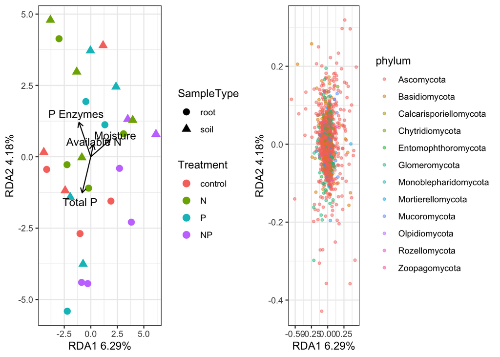

```r
# load library
library(gridExtra)

# set up dataframes for plotting the results
sit <- cbind(dat, scores(res, display='sites'))
spp <- cbind(data.frame(tax_table(phy)), scores(res, display='species'))
vec <- data.frame(scores(res, display='bp'))

# use these to adjust length of arrows and position of arrow labels
adj.vec <- 2
adj.txt <- 2.5

# 'site' ordination
p1 <- ggplot(sit, aes(x=RDA1, y=RDA2, color=Treatment, shape=SampleType)) +
  geom_point(size=3) +
  geom_segment(data=vec, inherit.aes=F,
               mapping=aes(x=0, y=0, xend=adj.vec*RDA1, yend=adj.vec*RDA2),
               arrow=arrow(length=unit(0.2, 'cm'))) +
  geom_text(data=vec, inherit.aes=F,
            mapping=aes(x=adj.txt*RDA1, y=adj.txt*RDA2,
                        label=c('Moisture', 'Total P', 'Available N', 'P Enzymes'))) +
  theme_bw()
p1$labels$x <- ord_labels(res)[1]
p1$labels$y <- ord_labels(res)[2]

# 'species' ordination
p2 <- ggplot(spp, aes(x=RDA1, y=RDA2, color=phylum)) +
  geom_point(size=1, alpha=0.5) +
  theme_bw()
p2$labels$x <- ord_labels(res)[1]
p2$labels$y <- ord_labels(res)[2]

# plot in two panels
grid.arrange(p1, p2, nrow=1)
```

# Variation partitioning - more than two tables

```r
# extract the OTU table
Y <- veganotu(phy)

# extract the sample data from the 'phyloseq' object
# then remove the 'SampleID' column
dat <- data.frame(sample_data(phy))
dat <- select(dat, -SampleID)

# use standardised categorical and continuous predictors in the constraint (X)
X <- ade4::dudi.mix(dat, scannf=F, nf=2)$tab
names(X)
```

```
##  [1] "Sampl.root"          "Sampl.soil"          "PlotI.3"
##  [4] "PlotI.4"             "PlotI.5"             "PlotI.8"
##  [7] "PlotI.16"            "PlotI.18"            "PlotI.21"
## [10] "PlotI.22"            "PlotI.29"            "PlotI.32"
## [13] "PlotI.33"            "PlotI.36"            "PlotI.40"
## [16] "PlotI.42"            "PlotI.44"            "PlotI.45"
## [19] "Block.1"             "Block.2"             "Block.3"
## [22] "Block.4"             "Treat.control"       "Treat.N"
## [25] "Treat.P"             "Treat.NP"            "Microbial_Biomass_C"
## [28] "Microbial_N"         "Microbial_P"         "Total_C_mg_g_soil"
## [31] "Total_N_mg_g_soil"   "Total_P_mg_g_soil"   "X..Moisture"
## [34] "DOC_Soil"            "Extractable_N_Soil"  "Extractable_P_Soil"
## [37] "BG_Enz"              "NAG_Enz"             "LAP_Enz"
## [40] "N_Enz"               "PHOS_Enz"            "CN_Enz"
## [43] "NP_Enz"              "CP_Enz"
```

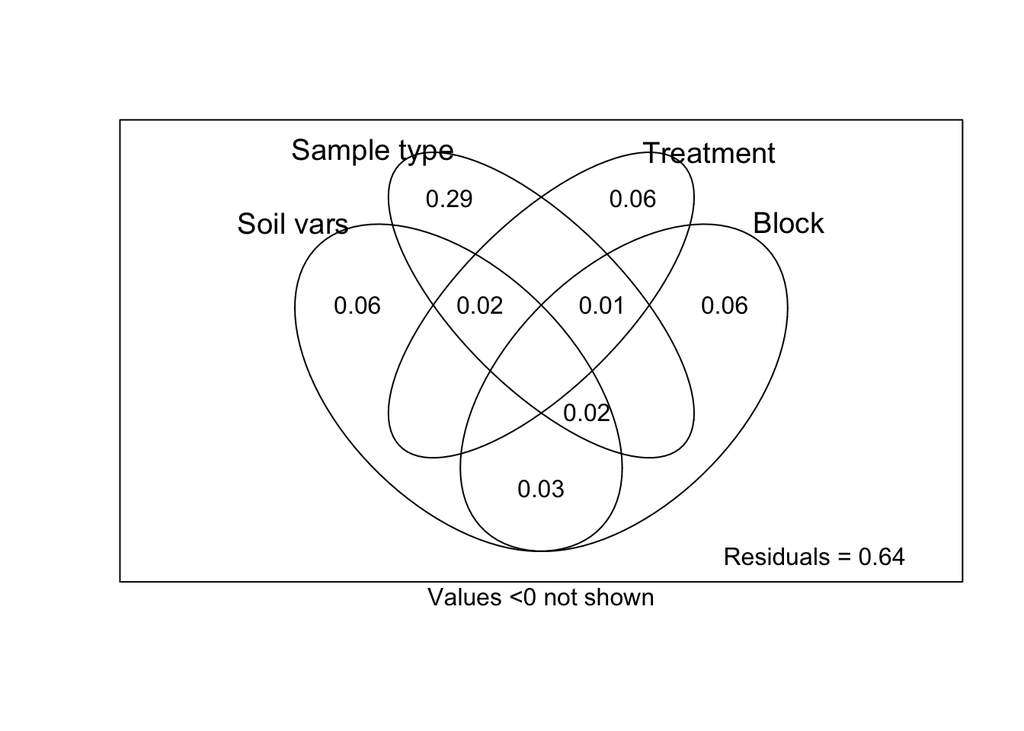

```r
# define the partitions
# soil variables from ordistep and envfit analyses
X1 <- X[, vars]
# sample type variables
X2 <- X[, grep('^Sampl', names(X), value=T)]
# treatment variables
X3 <- X[, grep('^Treat', names(X), value=T)]
# spatial variables ('BlockID')
X4 <- X[, grep('^Block', names(X), value=T)]

# partition variation and plot the result
vp <- varpart(Y, X1, X2, X3, X4)
plot(vp, Xnames=c('Soil vars', 'Sample type', 'Treatment', 'Block'))
```

We can test the significance of each partition by performing RDA and conditioning the OTU matrix with all of the other partitions than the one that we are focussing on in that analysis. For example:

```r
# Test the 'Treatment' partition (X3)
# first argument contains the community data
# second argument is the partition of interest (constraint)
# third argument is a column-bound dataframe of remaining partitions (condition)
rda.x3 <- rda(Y, X3, cbind(X1, X2, X4))

# test significance
anova(rda.x3)
```

```
## Permutation test for rda under reduced model
## Permutation: free
## Number of permutations: 999
##
## Model: rda(X = Y, Y = X3, Z = cbind(X1, X2, X4))
##          Df Variance      F Pr(>F)
## Model     3 0.064148 1.5605  0.002 **
## Residual 15 0.205542
## ---
## Signif. codes:  0 '***' 0.001 '**' 0.01 '*' 0.05 '.' 0.1 ' ' 1
```

```r
save.image('output/04.rdata')
```